# vssr_group_proj

Mai Ng

August 2, 2018

```r
library(dplyr)
```

```r
library(readr)
library(tidyr)
library(ggplot2)
library(ggthemes)  ## For dumbbell
library(ggalt)  ## For dumbbell
```

# Explore

```r
province_quintiles <- readr::read_csv("https://raw.githubusercontent.com/maiing/vssr-course/master/Day%201/province_quintiles.csv")
region_quintiles <- read_csv("https://raw.githubusercontent.com/maiing/vssr-course/master/Day%201/region_quintiles.csv")
```

## Check data format

```r
str(province_quintiles)
```

```
## Classes 'tbl_df', 'tbl' and 'data.frame':    63 obs. of  14 variables:
##  $ region                      : chr  "Red River Delta" "Red River Delta" "Red River Delta" "Red River Delta" ...
##  $ province                    : chr  "Ha Noi" "Vinh Phuc" "Bac Ninh" "Quang Ninh" ...
##  $ lowest_income_quintile_2010 : int  5420 4190 5340 4710 4410 5100 4200 4090 4180 4590 ...
##  $ highest_income_quintile_2010: int  48340 26590 38990 38120 26340 40690 24900 23840 24560 26350 ...
##  $ income_ratio_2010           : int  89 63 73 81 60 80 59 58 59 57 ...
##  $ lowest_income_quintile_2012 : int  8040 6290 8050 6890 7010 7590 6480 6140 5870 6210 ...
##  $ highest_income_quintile_2012: num  68290 40600 58310 54830 42070 ...
##  $ income_ratio_2012           : int  85 65 72 80 60 77 55 57 59 61 ...
##  $ lowest_income_quintile_2014 : int  12240 7940 12550 8160 9920 13190 7990 8880 7400 10590 ...
##  $ highest_income_quintile_2014: num  103680 51220 81600 65070 59590 ...
##  $ income_ratio_2014           : int  85 65 65 80 60 77 55 59 61 61 ...
##  $ lowest_income_quintile_2016 : int  15100 9620 15530 11300 11090 15370 11040 10010 9440 10860 ...
##  $ highest_income_quintile_2016: int  127910 62080 100920 90150 66670 118520 61290 59480 57400 66230 ...
##  $ income_ratio_2016           : int  85 65 65 80 60 77 55 59 61 61 ...
##  - attr(*, "spec")=List of 2
##   ..$ cols   :List of 14
##   .. ..$ region                      : list()
##   .. .. ..- attr(*, "class")= chr  "collector_character" "collector"
##   .. ..$ province                    : list()
##   .. .. ..- attr(*, "class")= chr  "collector_character" "collector"
##   .. ..$ lowest_income_quintile_2010 : list()
##   .. .. ..- attr(*, "class")= chr  "collector_integer" "collector"
##   .. ..$ highest_income_quintile_2010: list()
##   .. .. ..- attr(*, "class")= chr  "collector_integer" "collector"
##   .. ..$ income_ratio_2010           : list()
##   .. .. ..- attr(*, "class")= chr  "collector_integer" "collector"
##   .. ..$ lowest_income_quintile_2012 : list()
##   .. .. ..- attr(*, "class")= chr  "collector_integer" "collector"
##   .. ..$ highest_income_quintile_2012: list()
##   .. .. ..- attr(*, "class")= chr  "collector_double" "collector"
##   .. ..$ income_ratio_2012           : list()
##   .. .. ..- attr(*, "class")= chr  "collector_integer" "collector"
##   .. ..$ lowest_income_quintile_2014 : list()
##   .. .. ..- attr(*, "class")= chr  "collector_integer" "collector"
##   .. ..$ highest_income_quintile_2014: list()
##   .. .. ..- attr(*, "class")= chr  "collector_double" "collector"
##   .. ..$ income_ratio_2014           : list()
##   .. .. ..- attr(*, "class")= chr  "collector_integer" "collector"
##   .. ..$ lowest_income_quintile_2016 : list()
##   .. .. ..- attr(*, "class")= chr  "collector_integer" "collector"
##   .. ..$ highest_income_quintile_2016: list()
##   .. .. ..- attr(*, "class")= chr  "collector_integer" "collector"
##   .. ..$ income_ratio_2016           : list()
##   .. .. ..- attr(*, "class")= chr  "collector_integer" "collector"
##   ..$ default: list()
##   .. ..- attr(*, "class")= chr  "collector_guess" "collector"
##   ..- attr(*, "class")= chr "col_spec"
```

## Describe data

```r
summary(province_quintiles)
```

```
##     region            province         lowest_income_quintile_2010
##  Length:63          Length:63          Min.   :2150
##  Class :character   Class :character   1st Qu.:2965
##  Mode  :character   Mode  :character   Median :3630
##                                        Mean   :3934
##                                        3rd Qu.:4360
##                                        Max.   :9800
##  highest_income_quintile_2010 income_ratio_2010
##  Min.   :14130                Min.   :54.00
##  1st Qu.:21355                1st Qu.:64.50
##  Median :25390                Median :69.00
##  Mean   :27484                Mean   :70.29
##  3rd Qu.:29050                3rd Qu.:75.00
##  Max.   :70140                Max.   :94.00
##  lowest_income_quintile_2012 highest_income_quintile_2012
##  Min.   : 2730               Min.   :19280
##  1st Qu.: 4095               1st Qu.:28625
##  Median : 5030               Median :35780
##  Mean   : 5563               Mean   :39070
##  3rd Qu.: 6255               3rd Qu.:43135
##  Max.   :13020               Max.   :84470
##  income_ratio_2012 lowest_income_quintile_2014
##  Min.   :54.00     Min.   : 3510
##  1st Qu.:65.00     1st Qu.: 5095
##  Median :70.00     Median : 6780
##  Mean   :70.94     Mean   : 7373
##  3rd Qu.:77.00     3rd Qu.: 8545
##  Max.   :95.00     Max.   :18380
##  highest_income_quintile_2014 income_ratio_2014
##  Min.   : 25810               Min.   :54.00
##  1st Qu.: 36885               1st Qu.:65.00
##  Median : 48050               Median :70.00
##  Mean   : 51719               Mean   :71.24
##  3rd Qu.: 59300               3rd Qu.:77.00
##  Max.   :118950               Max.   :97.00
##  lowest_income_quintile_2016 highest_income_quintile_2016
##  Min.   : 4180               Min.   : 32370
##  1st Qu.: 6335               1st Qu.: 46530
##  Median : 8360               Median : 57860
##  Mean   : 8959               Mean   : 63411
##  3rd Qu.:10575               3rd Qu.: 70295
##  Max.   :21070               Max.   :136350
##  income_ratio_2016
##  Min.   :54.00
##  1st Qu.:65.00
##  Median :71.00
##  Mean   :72.02
##  3rd Qu.:78.50
##  Max.   :97.00
```

```r
table(province_quintiles$province)
```

```
##
##          An Giang Ba Ria - Vung Tau         Bac Giang           Bac Kan
##                 1                 1                 1                 1
##          Bac Lieu          Bac Ninh           Ben Tre         Binh Dinh
##                 1                 1                 1                 1
##        Binh Duong        Binh Phuoc        Binh Thuan            Ca Mau
##                 1                 1                 1                 1
##           Can Tho          Cao Bang           Da Nang           Dak Lak
##                 1                 1                 1                 1
##          Dak Nong         Dien Bien          Dong Nai         Dong Thap
##                 1                 1                 1                 1
##           Gia Lai          Ha Giang            Ha Nam            Ha Noi
##                 1                 1                 1                 1
##           Ha Tinh         Hai Duong         Hai Phong         Hau Giang
##                 1                 1                 1                 1
##  Ho Chi Minh city          Hoa Binh          Hung Yen        Khanh  Hoa
##                 1                 1                 1                 1
##       Kien  Giang           Kon Tum          Lai Chau          Lam Dong
##                 1                 1                 1                 1
##          Lang Son           Lao Cai           Long An          Nam Dinh
##                 1                 1                 1                 1
##           Nghe An       Ninh  Thuan         Ninh Binh           Phu Tho
##                 1                 1                 1                 1
##           Phu Yen        Quang  Nam       Quang  Ngai        Quang Binh
##                 1                 1                 1                 1
##        Quang Ninh         Quang Tri         Soc Trang            Son La
##                 1                 1                 1                 1
##          Tay Ninh         Thai Binh       Thai Nguyen         Thanh Hoa
##                 1                 1                 1                 1
##    Thua Thien-Hue        Tien Giang          Tra Vinh       Tuyen Quang
##                 1                 1                 1                 1
##         Vinh Long         Vinh Phuc           Yen Bai
##                 1                 1                 1
```

## Check missing values: No missing value

```r
colSums(is.na(province_quintiles))
```

```
##                       region                     province
##                            0                            0
##  lowest_income_quintile_2010 highest_income_quintile_2010
##                            0                            0
##            income_ratio_2010  lowest_income_quintile_2012
##                            0                            0
## highest_income_quintile_2012            income_ratio_2012
##                            0                            0
##  lowest_income_quintile_2014 highest_income_quintile_2014
##                            0                            0
##            income_ratio_2014  lowest_income_quintile_2016
##                            0                            0
## highest_income_quintile_2016            income_ratio_2016
##                            0                            0
```

## Manipulate data

#### Transform

```r
table(prov_long$year)
```

```
##
## 2010 2012 2014 2016
##  189  189  189  189
```

```r
table(prov_long$index)
```

```
##
## highest_income_quintile_2010 highest_income_quintile_2012
##                           63                           63
## highest_income_quintile_2014 highest_income_quintile_2016
##                           63                           63
##            income_ratio_2010            income_ratio_2012
##                           63                           63
##            income_ratio_2014            income_ratio_2016
##                           63                           63
##  lowest_income_quintile_2010  lowest_income_quintile_2012
##                           63                           63
##  lowest_income_quintile_2014  lowest_income_quintile_2016
##                           63                           63
```

# Viz

## Plot 1:

*Boxplot for highest and lowest throughout the years to see the trends in highest and lowest income. And of course, they went up, duh*

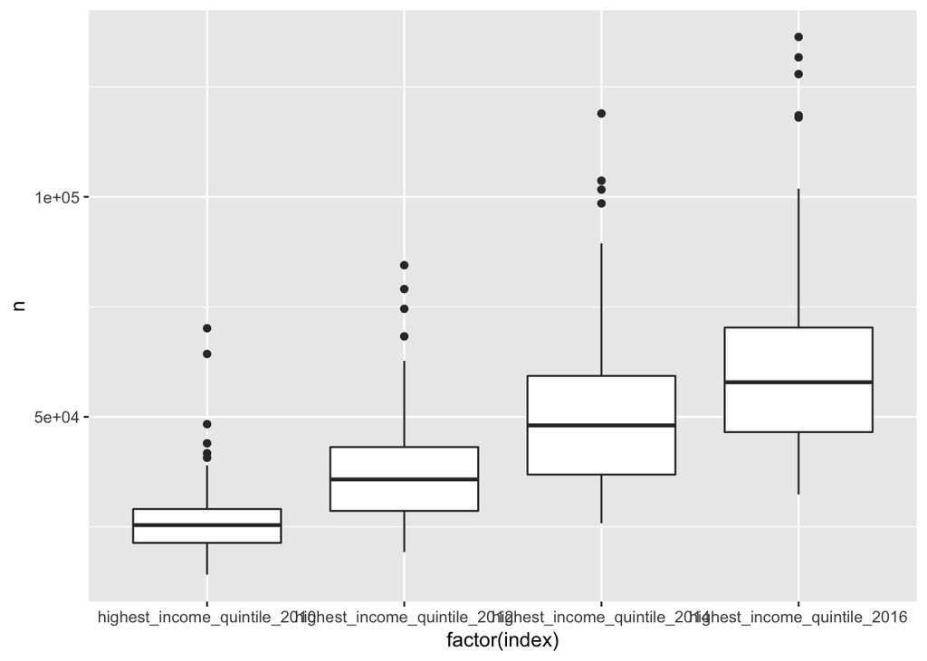

```r
high_boxplot <- ggplot(df_highest, aes(x=factor(index), y=n)) + geom_boxplot()
high_boxplot
```

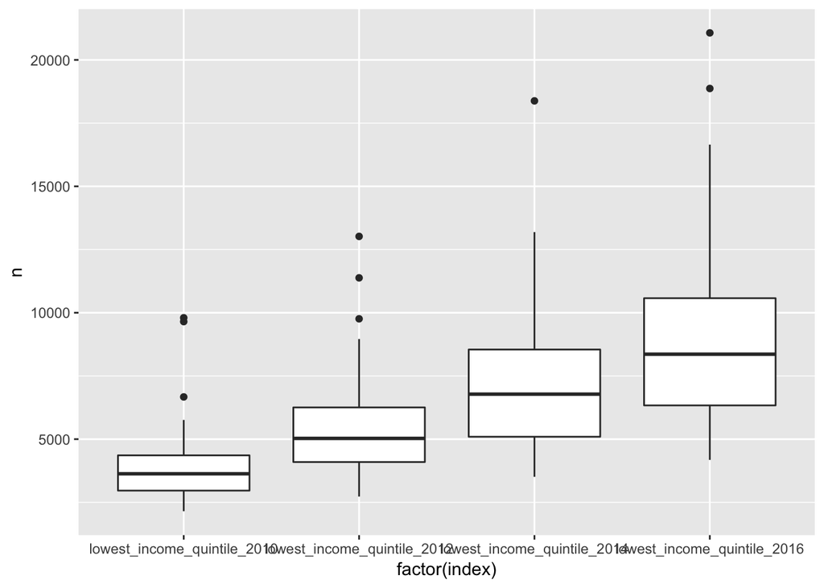

```r
low_boxplot <- ggplot(df_lowest, aes(x=factor(index), y=n)) + geom_boxplot()
low_boxplot
```

## Plot 2:

*I would like to see the ranking of all provinces as well as the changes in income gap among those provinces. So I started to think about provinces on y-axes and a line range between 2010 and 2016. Then idea about dumbbell came out. And I ran into this cool blog by Phi Nguyen. http://phinguyen.co/blog/visualizing-the-2015-2016-bundesliga-season-in-3-charts/ He has such a smart way to illustrate increase and decrease with dumbbell*

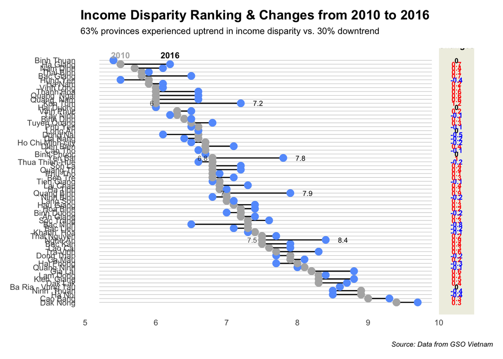

```r
#create dumbbell plots
p <- ggplot(prov_slim, aes(x=income_ratio_2010, xend=income_ratio_2016, y=province)) +
  geom_segment(aes(y=province, yend=province, x=5.2, xend= 9.9), color="#B2B2B2", size=0.15) +
  geom_dumbbell(aes(x=income_ratio_2010, xend=income_ratio_2016, y=province), size_x=3, colour_x="#B2B2B2") +
  geom_dumbbell(size_x=3,
                size_xend=3,
                colour_x="#B2B2B2",
                colour_xend='#649EFC'
                   ) +
  scale_y_discrete("province", expand=c(0.05,0)) +
  ggtitle("Income Disparity Ranking & Changes from 2010 to 2016") +
  labs(subtitle = "63% provinces experienced uptrend in income disparity vs. 30% downtrend",
       caption = "Source: Data from GSO Vietnam",
       x = "Income Disparity (Ratio of 20% Highest income to 20% Lowest Income") +
  theme_minimal() +
  theme(panel.grid = element_blank(),
        panel.grid.major.y = element_line(color = "gray90"),
        axis.line=element_blank(),
        axis.ticks=element_blank(),
        axis.title.x=element_blank(),
        axis.title.y=element_blank(),
        axis.text.y=element_text(size=8),
        axis.text.x=element_text(size=8),
        plot.title=element_text(face="bold"),
        plot.subtitle=element_text(size=9, margin=margin(b=12)),
        plot.caption=element_text(face="italic", size=7, margin=margin(t=14)), plot.margin=unit(rep(10, 4), "pt"))

p <- p + geom_text(data=filter(prov_slim, province %in% c('Kon Tum', 'Yen Bai', 'Quang Binh', 'Nghe An')),
            aes(x=income_ratio_2010, y=province, label=income_ratio_2010),
            #color="#B2B2B2",
            alpha=0.7,
            size=2.5,
            vjust=0.5,
            hjust=1.5) +
  geom_text(data=filter(prov_slim, province %in% c('Kon Tum', 'Yen Bai', 'Quang Binh', 'Nghe An')),
            aes(x=income_ratio_2016, y=province, label=income_ratio_2016),
            #color="#649EFC",
            size=2.5,
            vjust=0.5,
            hjust=-1.25)


p <- p + geom_text(data=filter(prov_slim, province=='Ha Giang'),
            aes(x=income_ratio_2010, y=province, label='2010'),
            color="#B2B2B2",
            size=3,
            vjust=-1,
            hjust=0.5,
            fontface="bold") +
  geom_text(data=filter(prov_slim, province=='Ha Giang'),
            aes(x=income_ratio_2016, y=province, label='2016'),
            size=3,
            vjust=-1,
            hjust=0.5,
            fontface="bold")


p <- p + geom_rect(aes(xmin=10, xmax=10.5, ymin=-Inf, ymax=Inf), fill="#EFEFE3") +
  geom_text(aes(label=Diff, y=province, x=10.25, color=prov_slim$colors),
            fontface="bold",
            size=2.5) +
  scale_color_manual(values=c('black','blue','red')) +
  geom_text(data=filter(prov_slim, province=='Binh Thuan'),
            aes(x=10.25, y=province, label='Changes'),
            size=3,
            vjust=-2,
            fontface='bold') +
            #color='#4D4D4D') +
  theme(legend.position='none')

p
```

## Plot 3: Highest vs Lowest income quintile in 2016

*Following the above graph, I was thinking: Do poor people experience a distince lowest income quintile? And as I have already had a bunch of code with dumbbell, there shouldn’t be any reason for me not to try out with this question. So here it is.*

**Obviously, there is not a too distinct in lowest income quintile among provinces, compared to highest income quintile.**

```r
prov_slim2 <-  select(province_quintiles, region, province, highest_income_quintile_2016, lowest_income_quintile_2016)
prov_slim2$province <- factor(prov_slim2$province)
prov_slim2$province <- reorder(prov_slim2$province, -prov_slim2$lowest_income_quintile_2016)
```

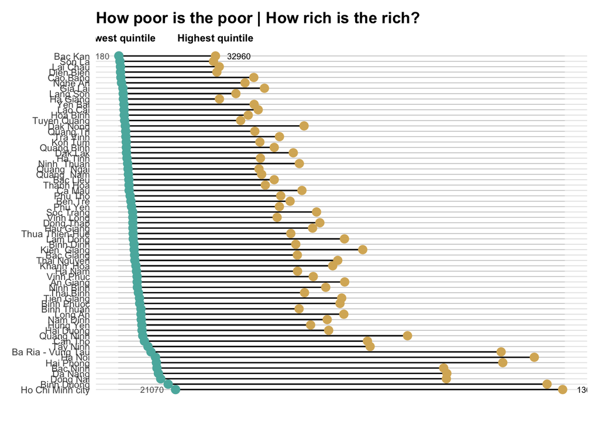

```r
#create dumbbell plots
p3 <- ggplot(prov_slim2, aes(x=lowest_income_quintile_2016, xend=highest_income_quintile_2016, y=province)) +
  geom_segment(aes(y=province, yend=province, x=4000, xend= 137000), color="#B2B2B2", size=0.15) +
  geom_dumbbell(aes(x=lowest_income_quintile_2016, xend=highest_income_quintile_2016, y=province), size_x=3, colour_x="#B2B2B2") +
  geom_dumbbell(size_x=3,
                size_xend=3,
                colour_x="#5ab4ac",
                colour_xend='#d8b365'
                   ) +
  scale_y_discrete("province", expand=c(0.07,0)) +
  ggtitle("How poor is the poor | How rich is the rich?") +
  # labs(subtitle = "63% provinces experienced uptrend in income disparity vs. 30% downtrend",
  #      caption = "Source: Data from GSO Vietnam",
  #      x = "Income Disparity (Ratio of 20% Highest income to 20% Lowest Income") +
  theme_minimal() +
  theme(panel.grid = element_blank(),
        panel.grid.major.y = element_line(color = "gray90"),
        axis.line=element_blank(),
        axis.ticks=element_blank(),
        axis.title.x=element_blank(),
        axis.title.y=element_blank(),
        axis.text.y=element_text(size=8),
        axis.text.x=element_blank(),
        plot.title=element_text(face="bold"),
        plot.subtitle=element_text(size=9, margin=margin(b=12)),
        plot.caption=element_text(face="italic", size=7, margin=margin(t=14)), plot.margin=unit(rep(10, 4), "pt"))


p3 <- p3 + geom_text(data=filter(prov_slim2, province %in% c('Bac Kan', 'Ho Chi Minh city')),
            aes(x=lowest_income_quintile_2016, y=province, label=lowest_income_quintile_2016),
            #color="#B2B2B2",
            alpha=0.7,
            size=2.5,
            vjust=0.5,
            hjust=1.5) +
  geom_text(data=filter(prov_slim2, province %in% c('Bac Kan', 'Ho Chi Minh city')),
            aes(x=highest_income_quintile_2016, y=province, label=highest_income_quintile_2016),
            #color="#649EFC",
            size=2.5,
            vjust=0.5,
            hjust=-0.5)


p3 <- p3 + geom_text(data=filter(prov_slim2, province=='Bac Kan'),
            aes(x=highest_income_quintile_2016, y=province, label='Highest quintile'),
            #color="#B2B2B2",
            size=3,
            vjust=-2,
            hjust=0.5,
            fontface="bold") +
  geom_text(data=filter(prov_slim2, province=='Bac Kan'),
            aes(x=lowest_income_quintile_2016, y=province, label='Lowest quintile'),
            size=3,
            vjust=-2,
            hjust=0.5,
            fontface="bold")

p3
```

```r
# p <- p + geom_rect(aes(xmin=10, xmax=10.5, ymin=-Inf, ymax=Inf), fill="#EFEFE3") +
#   geom_text(aes(label=Diff, y=province, x=10.25, color=prov_slim$colors),
#             fontface="bold",
#             size=2.5) +
#   scale_color_manual(values=c('black','blue','red')) +
#   geom_text(data=filter(prov_slim, province=='Binh Thuan'),
#             aes(x=10.25, y=province, label='Changes'),
#             size=3,
#             vjust=-2,
#             fontface='bold') +
#             #color='#4D4D4D') +
#   theme(legend.position='none')
#
# p
```